# Assignment 08

Krista Pipho, kp275

April 7, 2021

## Clustering

Load in libraries

```r
library(tidyverse)
library(RColorBrewer)
library(dendextend)
library(cluster)
library(datasets)
```

### Problem 1:

Using the built-in iris data set, create a distance matrix (using dist()) representing the Euclidean distance between each of the specimens (rows in the data frame). Make sure your distance matrix keeps the appropriate Species labels [2 pts]

```r
# Split the dataset into measures and species labels
measures.only <- iris %>% dplyr::select(-Species)
species.only <- as.vector(iris$Species)

# Turn measures into a matrix and label matrix rows with species
measures.only.m <- as.matrix(measures.only)
rownames(measures.only.m) <- species.only

# Calculate distance matrix
iris.dist <- dist(measures.only.m, method = "euclidean", diag = TRUE, upper = TRUE)
```

### Problem 2:

Carry out hierarchical clustering of the iris specimens using UPGMA aglommeration based on the distance matrix from Problem 1. Draw a dendrogram representing this clustering using the dendextend package, coloring the labels (see dendextend::labels_colors()) according to Species assignment. That is, all the setosa specimens should have labels with the same color, all the viriginica specimens should have labels in a different color, etc. [6 pts]

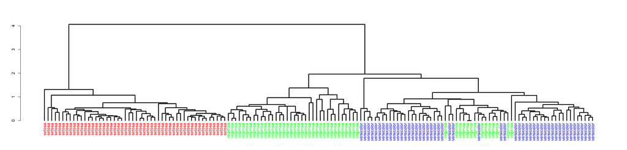

```r
# Calculate UPGMA clusters and convert to dendrogram
iris.tree <- hclust(iris.dist, method = "average")
dend <- as.dendrogram(iris.tree)

#For personal refference later
#colored.labs.dend <- ifelse(grepl("setosa", labels(dend)), "red", ifelse(grepl("versicolor", labels(dend)), "blue", "green"))
#dend2 <- assign_values_to_leaves_edgePar(dend=dend, value = colored.labs.dend, edgePar = "col")

# Color lables based on species
dendextend::labels_colors(dend) <- ifelse(grepl("setosa", labels(dend)), "red", ifelse(grepl("versicolor", labels(dend)), "blue", "green"))
dend <- set(dend, "branches_lwd", 3)

plot(dend)
```

### Problem 3:

Cut your UPGMA dendrogram to yield 3 clusters, and plot the dendrogram color the branches according to cluster assignment. [2 pts]

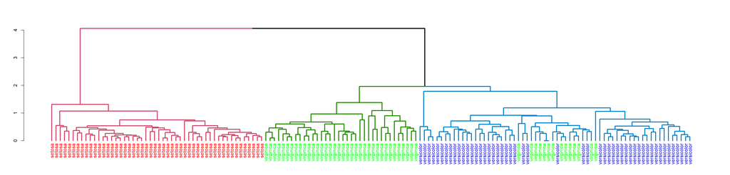

```r
# Color dendrogram based on clusters
plot(color_branches(dend, k=3))
```

### Problem 4:

Carry out k-medoids clustering of the iris specimen using the distance matrix from Problem 1, specifying three clusters [2 pts]

```r
iris.kmedoids <- pam(iris.dist, 3) # create k-medoids clustering with 8 clusters

kclusters <- iris.kmedoids$cluster
table(kclusters)
```

```
## kclusters
##  1  2  3
## 50 62 38
```

### Problem 5:

Generate a plot of the iris specimens in the space of the first two principal components (based on the covariance matrix). Color the specimens by their cluster membership according to the k-medoids clustering you carried out in the previous problem, and specify their shape by the Species label. [4 pts]

```r
# Calculate covriance matrix
cov(measures.only)
```

```
##              Sepal.Length Sepal.Width Petal.Length Petal.Width
## Sepal.Length    0.6856935  -0.0424340    1.2743154   0.5162707
## Sepal.Width    -0.0424340   0.1899794   -0.3296564  -0.1216394
## Petal.Length    1.2743154  -0.3296564    3.1162779   1.2956094
## Petal.Width     0.5162707  -0.1216394    1.2956094   0.5810063
```

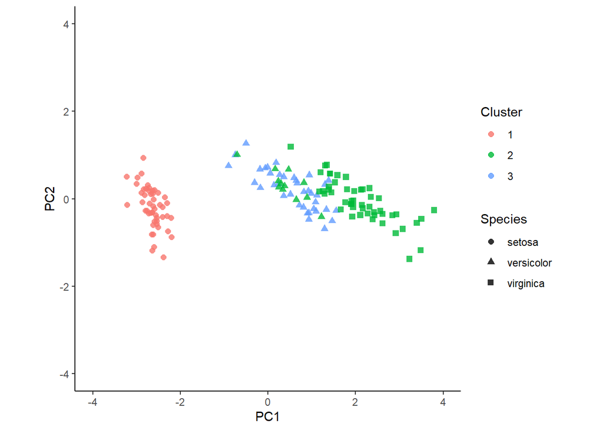

```r
# Run PCA analysis
measures.pca <- prcomp(measures.only, center=TRUE, retx=TRUE)

# Extract PCA scores from prcomp output
pca.scores.df <- as.data.frame(measures.pca$x)

# Define a coordinate system for the plot
coord.system <- coord_fixed(ratio=1, xlim=c(-4,4),ylim=c(-4,4))

# Isolate the species column and add it to the scores data
species.only <-
  iris %>%
  dplyr::select(Species)

# reorder genes so they match the dendrogram
Cluster <- as.factor(kclusters[order.dendrogram(dend)])

pca.scores.df <- cbind(pca.scores.df,species.only, Cluster)

# Plot
pc1v2 <-
  pca.scores.df %>%
  ggplot(aes(x = PC1, y= PC2, color = Cluster, shape = Species)) +
  geom_point(size = 2, alpha = .8) +
  coord.system + theme_classic()


pc1v2
```

### Problem 6:

Since we know the true Species groupings, it's straightforward to visually inspect the figures you made above to identify mis-clustered samples. By visual inspection, how many of the iris specimens are mis-clustered under the UPGMA clustering? By visual inspection, how many of the specimens are mis-clustered under the k-medoids clustering? [2 pts]

It looks like about 15 samples are mis-clustered under the UPGMA clustering. It is harder to visualy inspect the PCA plot than the dendrogram, but it looks like a similar number are mis-clustered using the medoid method (green triangles).